# MVA6_FactorAnalysis

Sai Madhuri

2024-03-22

```r
#Reading data
autompg <- read.csv("/Users/user/Downloads/auto-mpg.csv")
str(autompg)
```

```
## 'data.frame':    398 obs. of  9 variables:
##  $ mpg         : num  18 15 18 16 17 15 14 14 14 15 ...
##  $ cylinders   : int  8 8 8 8 8 8 8 8 8 8 ...
##  $ displacement: num  307 350 318 304 302 429 454 440 455 390 ...
##  $ horsepower  : chr  "130" "165" "150" "150" ...
##  $ weight      : int  3504 3693 3436 3433 3449 4341 4354 4312 4425 3850 ...
##  $ acceleration: num  12 11.5 11 12 10.5 10 9 8.5 10 8.5 ...
##  $ model.year  : int  70 70 70 70 70 70 70 70 70 70 ...
##  $ origin      : int  1 1 1 1 1 1 1 1 1 1 ...
##  $ car.name    : chr  "chevrolet chevelle malibu" "buick skylark 320" "plymouth satellite" "amc rebel sst" ...
```

```r
autompg$horsepower <- as.integer(autompg$horsepower)
str(autompg)
```

```
## 'data.frame':    398 obs. of  9 variables:
##  $ mpg         : num  18 15 18 16 17 15 14 14 14 15 ...
##  $ cylinders   : int  8 8 8 8 8 8 8 8 8 8 ...
##  $ displacement: num  307 350 318 304 302 429 454 440 455 390 ...
##  $ horsepower  : int  130 165 150 150 140 198 220 215 225 190 ...
##  $ weight      : int  3504 3693 3436 3433 3449 4341 4354 4312 4425 3850 ...
##  $ acceleration: num  12 11.5 11 12 10.5 10 9 8.5 10 8.5 ...
##  $ model.year  : int  70 70 70 70 70 70 70 70 70 70 ...
##  $ origin      : int  1 1 1 1 1 1 1 1 1 1 ...
##  $ car.name    : chr  "chevrolet chevelle malibu" "buick skylark 320" "plymouth satellite" "amc rebel sst" ...
```

```r
# cleaning data
auto1 <- na.omit(autompg)
```

```r
# load library for factor analysis
library(ggplot2)
library(psych)
```

#1.Decide how many Factors are ideal for your dataset?

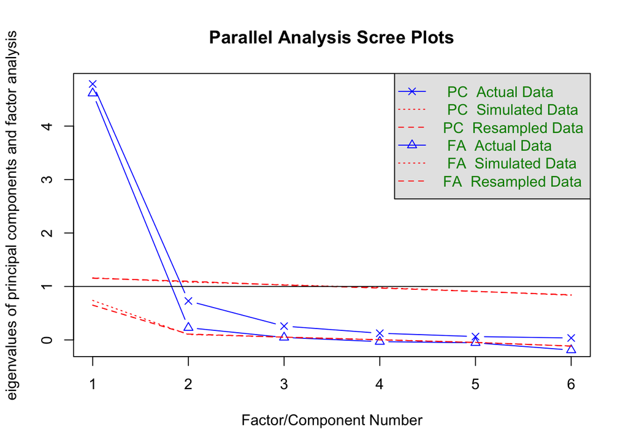

```
## Parallel analysis suggests that the number of factors =  2  and the number of components =  1
```

```r
data <- auto1[,1:6]
#To answer question 1 we perform Parallel analysis Scree Plots
fa.parallel(data)
```

#Output:Parallel analysis suggests that the number of factors = 2 and the number of components = 1

#From the above two factors are ideal for the autompg dataset

#2.Explain the output for your factor model?

```r
fit.pc <- principal(data, nfactors=2, rotate="varimax")
fit.pc
```

```
## Principal Components Analysis
## Call: principal(r = data, nfactors = 2, rotate = "varimax")
## Standardized loadings (pattern matrix) based upon correlation matrix
##                RC1   RC2   h2    u2 com
## mpg          -0.88 -0.20 0.81 0.194 1.1
## cylinders     0.90  0.30 0.90 0.096 1.2
## displacement  0.91  0.35 0.95 0.049 1.3
## horsepower    0.79  0.55 0.92 0.077 1.8
## weight        0.95  0.20 0.95 0.055 1.1
## acceleration -0.23 -0.97 0.99 0.011 1.1
##
##                        RC1  RC2
## SS loadings           3.99 1.53
## Proportion Var        0.66 0.25
## Cumulative Var        0.66 0.92
## Proportion Explained  0.72 0.28
## Cumulative Proportion 0.72 1.00
##
## Mean item complexity =  1.3
## Test of the hypothesis that 2 components are sufficient.
##
## The root mean square of the residuals (RMSR) is  0.03
##  with the empirical chi square  11.49  with prob <  0.022
##
## Fit based upon off diagonal values = 1
```

#High absolute values (close to 1) indicate a strong relationship between the variable and the factor. ->Example: For displacement variable, among the two factors (RC1,RC2), RC1 is having high absolute value so we can conclude that displacement variable is explained better by RC1. Like this we can analyze the relationship between the variables and the factors.

#h2 explains how much variance of the variables are explained by the factors. ->Example: For displacement variable, 0.950 of it’s variance is explained by the factors

#u2 indicates the amount of variance not explained by the factors ->Example: For displacement variable, 0.049 of it’s variance is unique and not explained by the factors.

#Principal Components Analysis

Call: principal(r = data, nfactors = 2, rotate = “varimax”) Standardized loadings (pattern matrix) based upon correlation matrix

[output not shown]

SS loadings 3.99 1.53 Proportion Var 0.66 0.25 Cumulative Var 0.66 0.92 Proportion Explained 0.72 0.28 Cumulative Proportion 0.72 1.00

Mean item complexity = 1.3 Test of the hypothesis that 2 components are sufficient.

The root mean square of the residuals (RMSR) is 0.03 with the empirical chi square 11.49 with prob < 0.022

Fit based upon off diagonal values = 1

```r
round(fit.pc$values, 3)
```

```
## [1] 4.788 0.729 0.258 0.125 0.063 0.036
```

```r
fit.pc$loadings
```

```
##
## Loadings:
##              RC1    RC2
## mpg          -0.875 -0.200
## cylinders     0.901  0.305
## displacement  0.911  0.348
## horsepower    0.788  0.549
## weight        0.952  0.199
## acceleration -0.234 -0.966
##
##                  RC1   RC2
## SS loadings    3.989 1.528
## Proportion Var 0.665 0.255
## Cumulative Var 0.665 0.919
```

```r
# Communalities
fit.pc$communality
```

```
##          mpg    cylinders displacement   horsepower       weight acceleration
##    0.8058710    0.9039134    0.9505252    0.9225211    0.9454138    0.9886527
```

```r
# Rotated factor scores, Notice the columns ordering: RC1, RC2
fit.pc$scores
```

[output not shown]

[output cut: 378 more lines]

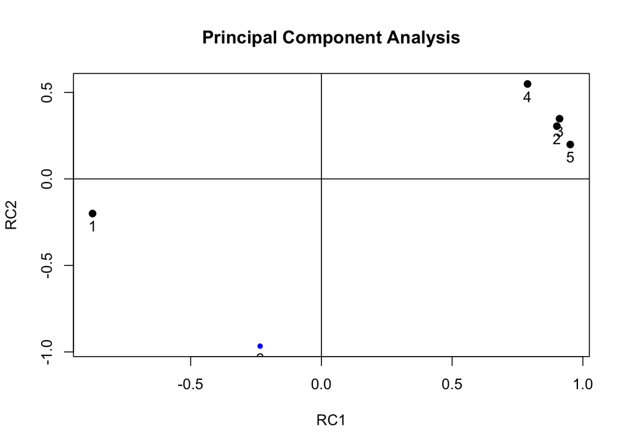

```r
fa.plot(fit.pc) # See Correlations within Factors
```

#3.Show the columns that go into each factor?

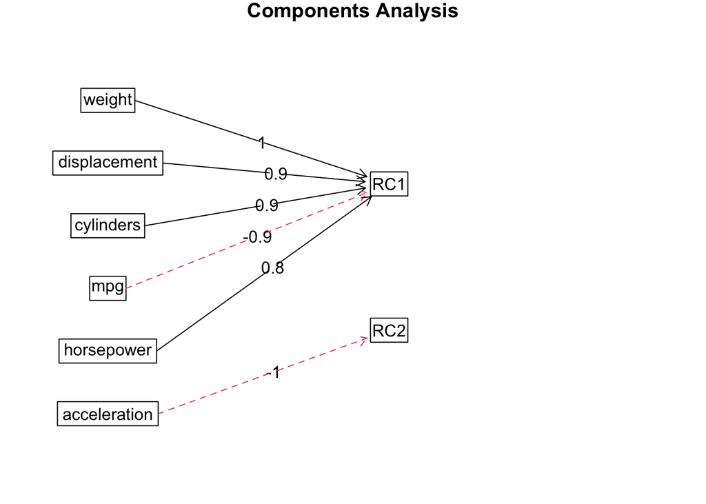

```r
fa.diagram(fit.pc) # Visualize the relationship
```

#From the above we can infer that weight,displacement,cylinders,mpg are well explained by RC1 and acceleration is explained better by RC2.

#4.Perform some visualizations using the factors?

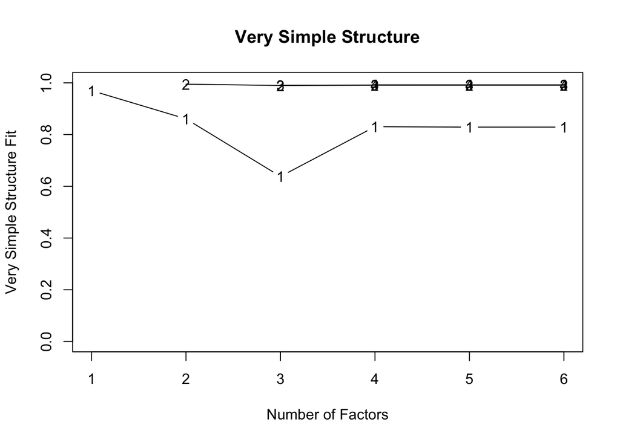

```
##
## Very Simple Structure
## Call: vss(x = data)
## VSS complexity 1 achieves a maximimum of 0.97  with  1  factors
## VSS complexity 2 achieves a maximimum of 0.99  with  2  factors
##
## The Velicer MAP achieves a minimum of 0.14  with  1  factors
## BIC achieves a minimum of  97.18  with  2  factors
## Sample Size adjusted BIC achieves a minimum of  109.87  with  2  factors
##
## Statistics by number of factors
##   vss1 vss2  map dof   chisq    prob sqresid  fit RMSEA BIC SABIC complex
## 1 0.97 0.00 0.14   9 3.7e+02 8.4e-74    0.71 0.97  0.32 314   343     1.0
## 2 0.86 0.99 0.16   4 1.2e+02 3.2e-25    0.12 0.99  0.27  97   110     1.3
## 3 0.64 0.99 0.29   0 9.8e-01      NA    0.22 0.99    NA  NA    NA     1.5
## 4 0.83 0.99 0.49  -3 3.2e-07      NA    0.19 0.99    NA  NA    NA     1.5
## 5 0.83 0.99 1.00  -5 3.5e-08      NA    0.19 0.99    NA  NA    NA     1.5
## 6 0.83 0.99   NA  -6 3.5e-08      NA    0.19 0.99    NA  NA    NA     1.5
##    eChisq    SRMR eCRMS eBIC
## 1 3.7e+01 5.6e-02 0.072  -17
## 2 2.0e+00 1.3e-02 0.025  -22
## 3 8.8e-03 8.7e-04    NA   NA
## 4 2.8e-09 4.8e-07    NA   NA
## 5 3.3e-10 1.7e-07    NA   NA
## 6 3.3e-10 1.7e-07    NA   NA
```

```r
#very simple structure visualization
vss(data)
```

#output Very Simple Structure Call: vss(x = data) VSS complexity 1 achieves a maximimum of 0.97 with 1 factors VSS complexity 2 achieves a maximimum of 0.99 with 2 factors

The Velicer MAP achieves a minimum of 0.14 with 1 factors BIC achieves a minimum of 97.18 with 2 factors Sample Size adjusted BIC achieves a minimum of 109.87 with 2 factors

```r
# Computing Correlation Matrix
corrm.auto <- cor(data)
corrm.auto
```

```
##                     mpg  cylinders displacement horsepower     weight
## mpg           1.0000000 -0.7776175   -0.8051269 -0.7784268 -0.8322442
## cylinders    -0.7776175  1.0000000    0.9508233  0.8429834  0.8975273
## displacement -0.8051269  0.9508233    1.0000000  0.8972570  0.9329944
## horsepower   -0.7784268  0.8429834    0.8972570  1.0000000  0.8645377
## weight       -0.8322442  0.8975273    0.9329944  0.8645377  1.0000000
## acceleration  0.4233285 -0.5046834   -0.5438005 -0.6891955 -0.4168392
##              acceleration
## mpg             0.4233285
## cylinders      -0.5046834
## displacement   -0.5438005
## horsepower     -0.6891955
## weight         -0.4168392
## acceleration    1.0000000
```

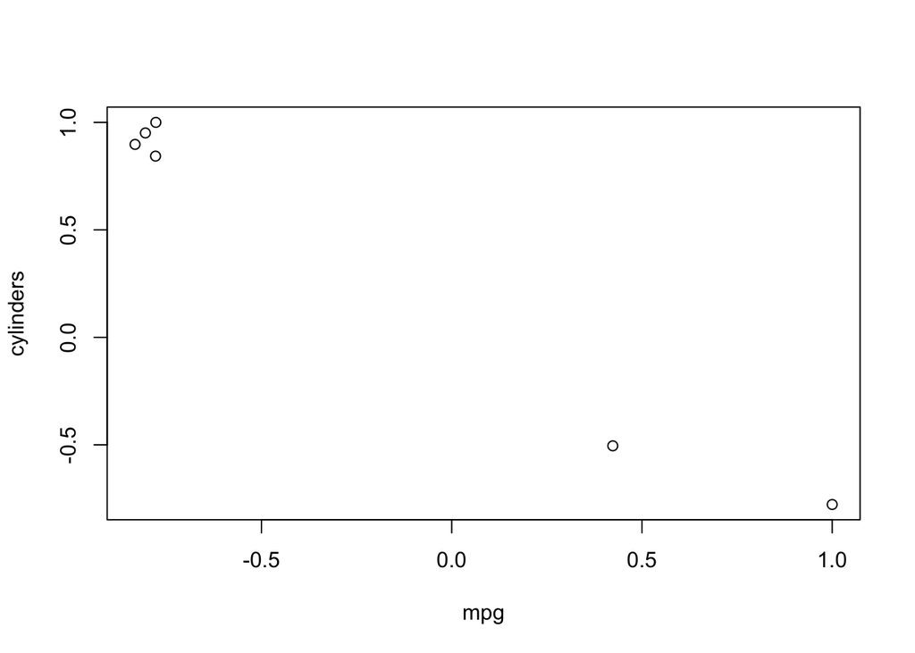

```r
plot(corrm.auto)
```

```r
auto_pca <- prcomp(data, scale=TRUE)
summary(auto_pca)
```

```
## Importance of components:
##                          PC1    PC2     PC3     PC4     PC5     PC6
## Standard deviation     2.188 0.8536 0.50840 0.35380 0.25135 0.19048
## Proportion of Variance 0.798 0.1214 0.04308 0.02086 0.01053 0.00605
## Cumulative Proportion  0.798 0.9195 0.96256 0.98342 0.99395 1.00000
```

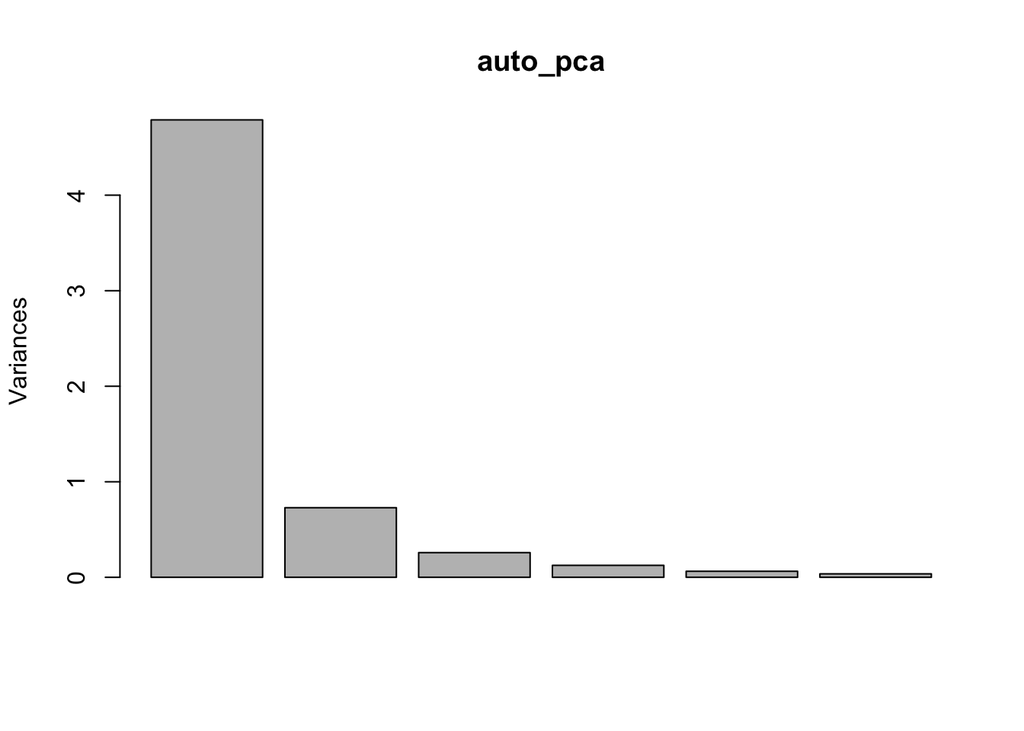

```r
plot(auto_pca)
```

#Biplot Visualization

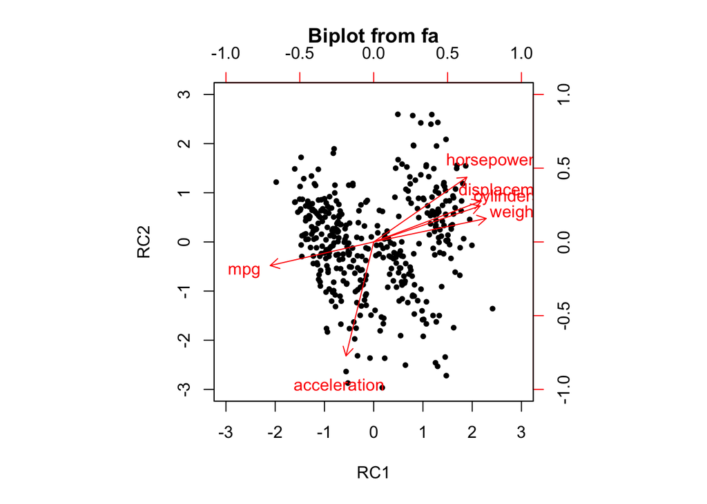

```r
biplot(fit.pc)
```